# Analyse des données de Transcriptomique Spacial Xenium de 10X Génomique

Myriam Feumi Bathanga & Emna Trigui & Yasmine Gbian Sinakouro

2026-04-25

```r
library(Seurat)
library(hdf5r)
```

```r
library(ggplot2)
library(arrow)
library(dplyr)
library(patchwork)
library(ape)
```

Importaion et traitement des données en utilisant la library arrow

```r
rep1 <- LoadXenium(data.dir = "C:/Users/myria/Documents/Rep1",
                   fov = "fov")
```

```
## Cell_seg columns: cell_id
```

```
## Adding default segmentation_method = 'cell'
```

```
## Genome matrix has multiple modalities, returning a list of matrices for this genome
```

```r
# Retirer les replicats avec 0 counts
rep1 <- subset(rep1, subset = nCount_Xenium > 0)
rep2 <- LoadXenium(data.dir = "C:/Users/myria/Documents/Rep2",
                   fov = "fov")
```

```
## Cell_seg columns: cell_id
```

```
## Adding default segmentation_method = 'cell'
```

```
## Genome matrix has multiple modalities, returning a list of matrices for this genome
```

```r
# Retirer les replicats avec 0 counts
rep2 <- subset(rep2, subset = nCount_Xenium > 0)
```

Organisation de nos objets Seurat

```r
rep1$orig.ident <- "Replicat_1"
rep2$orig.ident <- "Replicat_2"
```

Fusionner nos deux objets rep1 et rep2 et observer leur conposition en gènes et en cellules

```r
merged_qc = merge(rep1, rep2)
#composition du nouvel onjet fusionné (nombre de gènes et de cellules)
dim(merged_qc)
```

```
## [1]    313 285054
```

```r
#compoisition dans chacun des replicats fussionés
table(merged_qc$orig.ident)
```

```
##
## Replicat_1 Replicat_2
##     166363     118691
```

Visualiser les données avant le filtre

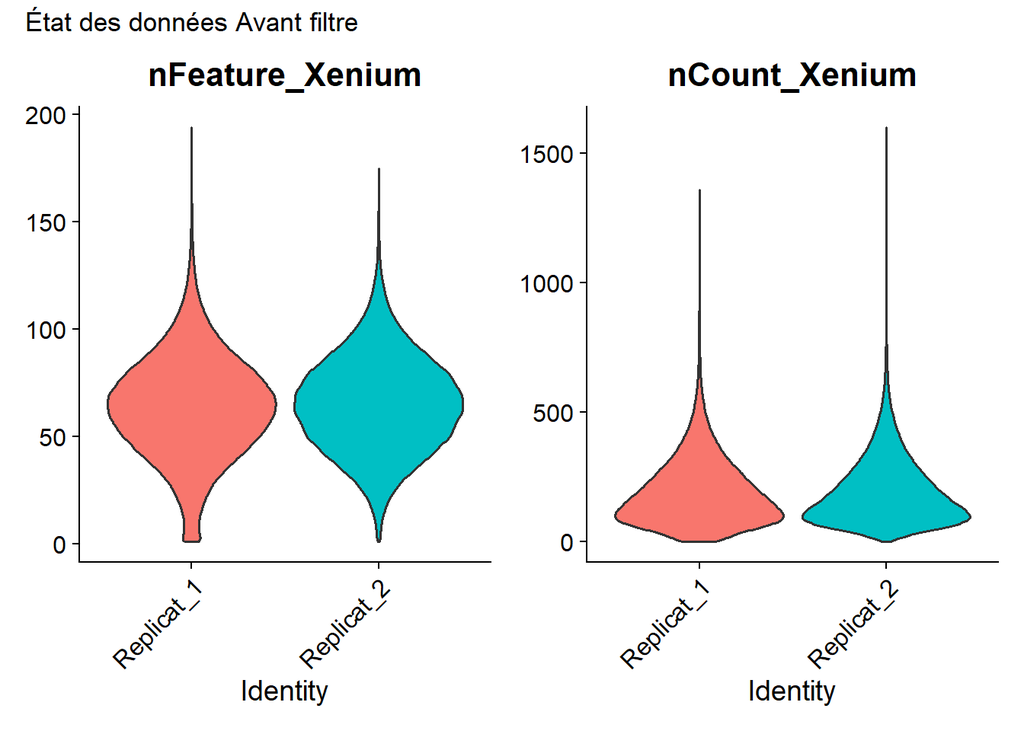

```r
p_avant_filtre = VlnPlot(
  merged_qc,
  features = c("nFeature_Xenium", "nCount_Xenium"),
  group.by = "orig.ident", # Aligne Rep1, Rep2 côte à côte
  ncol = 2,
  pt.size = 0,
  same.y.lims = FALSE
)  + plot_annotation(
  title = "État des données Avant filtre"
)
p_avant_filtre
```

Controle qualité des données pour filtrer les données avec peut de pertinances biologiques et limiter les bruits

```r
merged_filtered <- subset(merged_qc, subset = nFeature_Xenium > 25 & nFeature_Xenium < 130 & nCount_Xenium < 520)
dim(merged_filtered)
```

```
## [1]    313 264749
```

```r
table(merged_filtered$orig.ident)
```

```
##
## Replicat_1 Replicat_2
##     152871     111878
```

Visualiser les données parès le QC

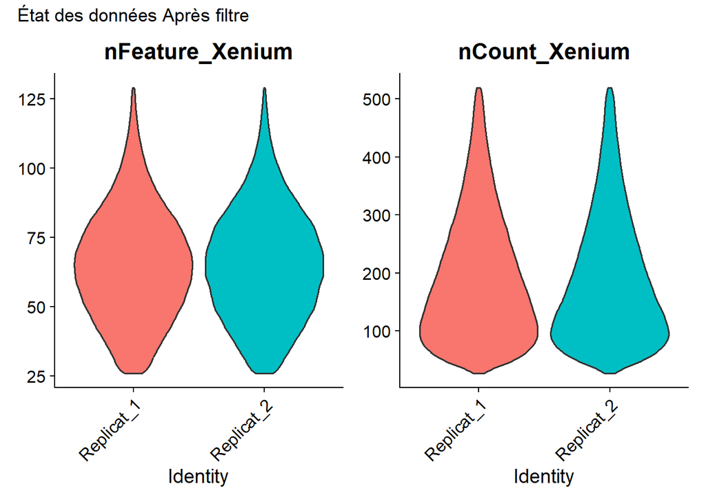

```r
p_apres_filtre = VlnPlot(
  merged_filtered,
  features = c("nFeature_Xenium", "nCount_Xenium"),
  group.by = "orig.ident", # Aligne Rep1, Rep2 côte à côte
  ncol = 2,
  pt.size = 0,
  same.y.lims = FALSE
)  + plot_annotation(
  title = "État des données Après filtre"
)
p_apres_filtre
```

Normalisation des données avec SCTransform

```r
merged_filtered <- SCTransform(merged_filtered, assay = "Xenium")
```

```
## Running SCTransform on assay: Xenium
```

```
## vst.flavor='v2' set. Using model with fixed slope and excluding poisson genes.
```

[output not shown]

```
## Calculating cell attributes from input UMI matrix: log_umi
```

```
## Variance stabilizing transformation of count matrix of size 313 by 152871
```

```
## Model formula is y ~ log_umi
```

```
## Get Negative Binomial regression parameters per gene
```

```
## Using 312 genes, 5000 cells
```

```
## Second step: Get residuals using fitted parameters for 313 genes
```

```
## Computing corrected count matrix for 313 genes
```

```
## Wall clock passed: Time difference of 4.235636 mins
```

```
## Determine variable features
```

```
## Centering data matrix
```

```
## Place corrected count matrix in counts slot
```

```
## vst.flavor='v2' set. Using model with fixed slope and excluding poisson genes.
```

[output not shown]

```
## Calculating cell attributes from input UMI matrix: log_umi
```

```
## Variance stabilizing transformation of count matrix of size 313 by 111878
```

```
## Model formula is y ~ log_umi
```

```
## Get Negative Binomial regression parameters per gene
```

```
## Using 311 genes, 5000 cells
```

```
## Second step: Get residuals using fitted parameters for 313 genes
```

```
## Computing corrected count matrix for 313 genes
```

```
## Wall clock passed: Time difference of 4.025625 mins
```

```
## Determine variable features
```

```
## Centering data matrix
```

```
## Place corrected count matrix in counts slot
```

```
## Set default assay to SCT
```

Réduction de dimmention avec PCA

```r
merged_filtered <- RunPCA(merged_filtered, assay = "SCT", verbose = FALSE)
```

Visualisation elbowPlot des PCs

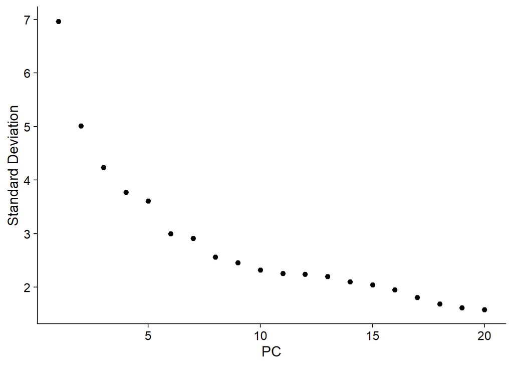

```r
ElbowPlot(merged_filtered)
```

Réduction de dimmention avec UMAP et clustering.

```r
merged_filtered <- RunUMAP(merged_filtered, dims = 1:20)
merged_filtered <- FindNeighbors(merged_filtered, reduction = "pca", dims = 1:20)
merged_filtered <- FindClusters(merged_filtered, resolution = 0.5)
```

```
## Modularity Optimizer version 1.3.0 by Ludo Waltman and Nees Jan van Eck
##
## Number of nodes: 264749
## Number of edges: 8068321
##
## Running Louvain algorithm...
## Maximum modularity in 10 random starts: 0.9189
## Number of communities: 17
## Elapsed time: 444 seconds
```

Visualisation UMAP

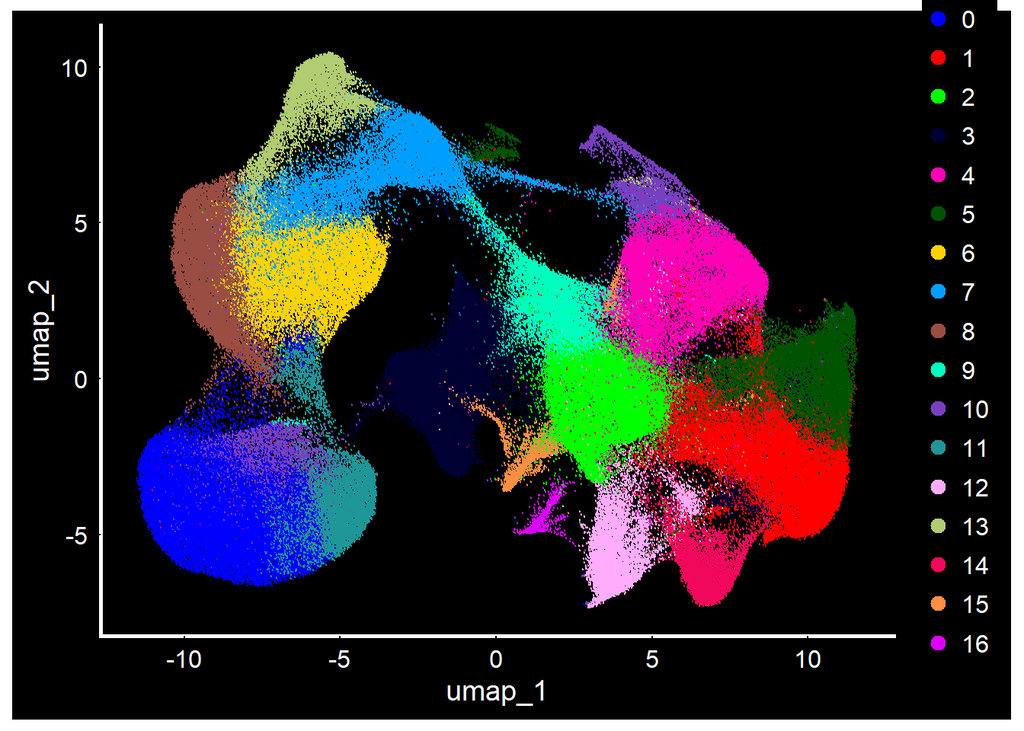

```r
DimPlot(merged_filtered, raster = FALSE, cols = 'glasbey') + DarkTheme() +coord_fixed()
```

```r
dim(merged_filtered)
```

```
## [1]    313 264749
```

Observer le nombre de cellules dans chaque cluster

```r
n_cells <- as.data.frame(table(Idents(merged_filtered)))
colnames(n_cells) <- c("Cluster", "Nombre_de_Cellules")
print(n_cells)
```

```
##    Cluster Nombre_de_Cellules
## 1        0              37301
## 2        1              31773
## 3        2              23842
## 4        3              23178
## 5        4              22511
## 6        5              16872
## 7        6              16828
## 8        7              16396
## 9        8              15801
## 10       9              12433
## 11      10              10532
## 12      11               9515
## 13      12               9379
## 14      13               7322
## 15      14               6792
## 16      15               2883
## 17      16               1391
```

Identification des markers des différents clusters et visualistaion

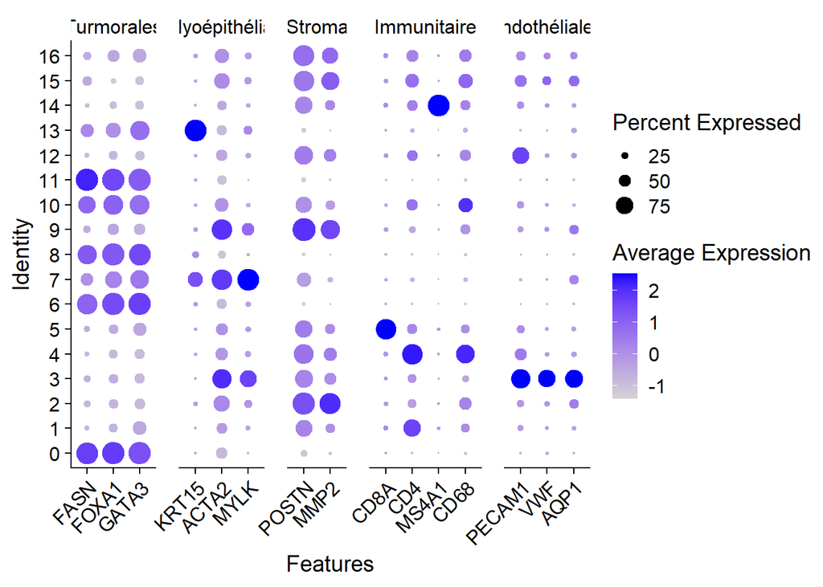

```r
genes_ident = list(
 Turmorales = c("FASN", "FOXA1", "GATA3"),
 Myoépithélial = c("KRT15", "ACTA2", "MYLK"),
 Stroma = c("POSTN", "MMP2"),
 Immunitaire = c("CD8A", "CD4", "MS4A1", "CD68"),
 endothéliales = c("PECAM1", "VWF", "AQP1")
)

dot2 = DotPlot(merged_filtered, features = genes_ident) + RotatedAxis()
dot2
```

Identifier les différents cluster à partir des markers et visualisation

```
## Rasterizing points since number of points exceeds 100,000.
## To disable this behavior set `raster=FALSE`
```

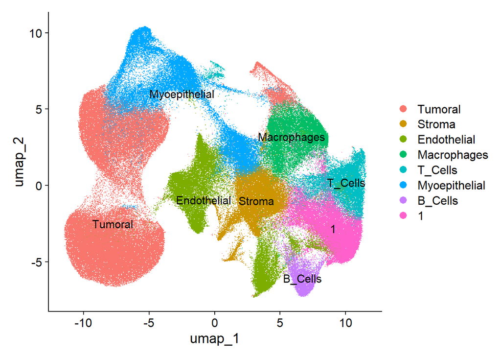

```r
new_names <- c(
  "0" = "Tumoral", "2" = "Stroma",
  "3" = "Endothelial", "4" = "Macrophages", "5" = "T_Cells",
  "6" = "Tumoral", "7" = "Myoepithelial", "8" = "Tumoral",
  "9" = "Myoepithelial", "10" = "Tumoral", "11" = "Tumoral",
  "12" = "Endothelial", "13" = "Myoepithelial", "14" = "B_Cells",
  "15" = "Stroma", "16" = "Stroma"
)

merged_filtered <- RenameIdents(merged_filtered, new_names)

DimPlot(merged_filtered, reduction = "umap", label = TRUE)
```

Visualisation du microenvironnement tissulaire (visualisation globale)

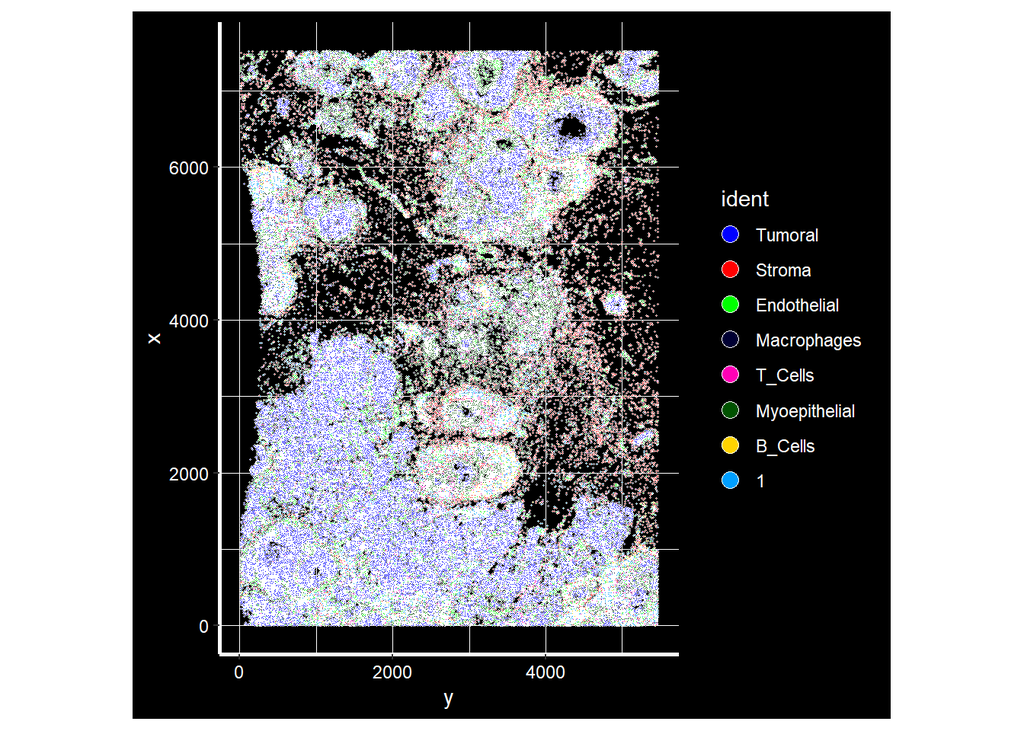

```r
imtissu = ImageDimPlot(merged_filtered, axes = TRUE, cols = 'glasbey') + DarkTheme()
imtissu
```

Visualiser comment les cellules s’étendes dans le tissu (de la dispersion de chaque type cellulaire dans le tissus)

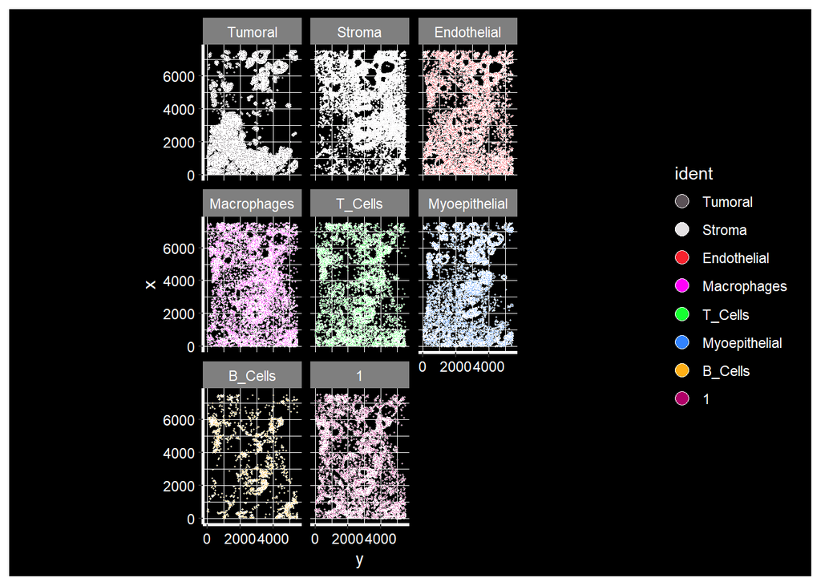

```r
ImageDimPlot(merged_filtered,
             split.by = "ident",
             axes = TRUE,
             cols = "polychrome",
             size = 0.5,
             dark.background = TRUE)
```

Zoomer sur certaines zones spéciphique pour mieux apprécier la localisation des cellules

```
## ℹ Adding new coordinate system, which will replace the existing one.
```

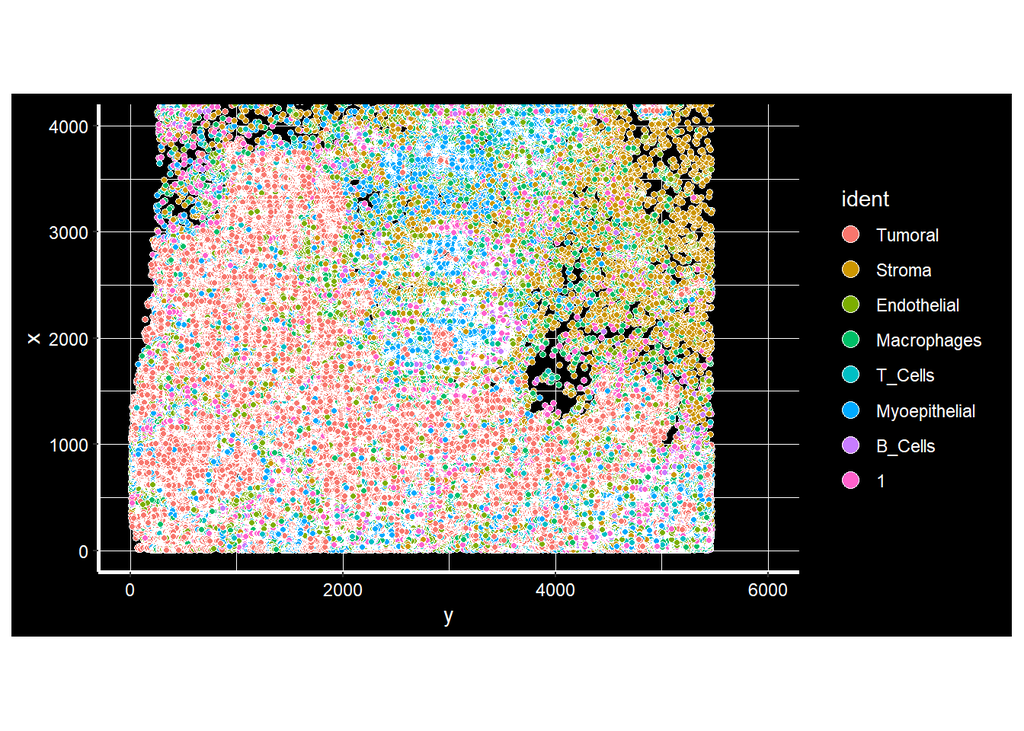

```r
ImageDimPlot(merged_filtered, fov = "fov", axes = TRUE, size = 1.5) +
  coord_fixed(xlim = c(0, 6000), ylim = c(0, 4000))
```

```r
#les coordonnées x et y en fonction de la zone que l,on veux observée à partir du plot de visualisation global.
```

Calcul et représentation graphique des proportions de chaque types cellulaires dans la coupe tissulaire

```r
prop.table(table(Idents(merged_filtered))) * 100
```

```
##
##       Tumoral        Stroma   Endothelial   Macrophages       T_Cells
##     33.985775     10.619870     12.297308      8.502771      6.372829
## Myoepithelial       B_Cells             1
##     13.654820      2.565449     12.001178
```

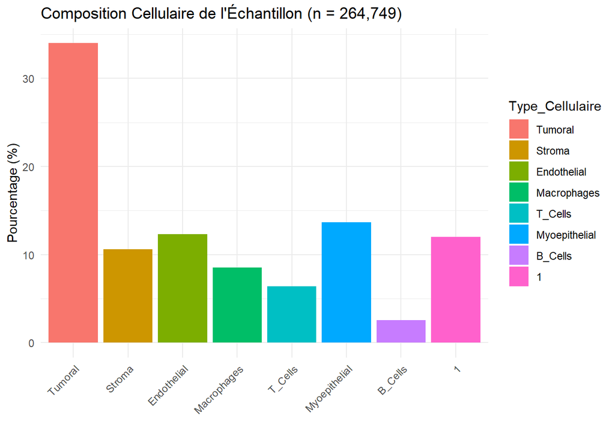

```r
df_stats <- as.data.frame(prop.table(table(Idents(merged_filtered))) * 100)
colnames(df_stats) <- c("Type_Cellulaire", "Pourcentage")

# Créer le barplot  du pourcentage de chaque types cellulaire dans ce tssu
ggplot(df_stats, aes(x = Type_Cellulaire, y = Pourcentage, fill = Type_Cellulaire)) +
  geom_bar(stat = "identity") +
  theme_minimal() +
  labs(title = "Composition Cellulaire de l'Échantillon (n = 264,749)",
       y = "Pourcentage (%)", x = "") +
  theme(axis.text.x = element_text(angle = 45, hjust = 1))
```